# Research

2024-03-26

```r
#Loading Required Library
library(ggplot2)
library(dplyr)
library(corrplot)
library(pwr2)
```

```r
#Loading Provided Dataset
CW = read.csv('Coursework.csv', stringsAsFactors = T)
summary(CW)
```

```
##     BatchID            AI              HE            Complexity Explain
##  Min.   : 1.00   Min.   :85.90   Min.   :82.70   Difficult:18   Off:25
##  1st Qu.:13.25   1st Qu.:92.78   1st Qu.:89.72   Moderate : 7   On :25
##  Median :25.50   Median :94.15   Median :92.30   Simple   :25
##  Mean   :25.50   Mean   :94.35   Mean   :92.10
##  3rd Qu.:37.75   3rd Qu.:96.47   3rd Qu.:94.40
##  Max.   :50.00   Max.   :99.90   Max.   :99.70
##        Type
##  Negative:31
##  Positive:19
##
##
##
##
```

# Breakdown of Dataset

BatchID is simply a label identifying a specific batch of classification problems. AI average % classification accuracy of the AI system on each batch of problems. HE average % classification accuracy of human experts on each batch of problems. Complexity is a category representing the typical complexity of the classification tasks within each batch of problems, with possible values {Simple, Moderate, Difficult}. Explain is a category representing two possible values of a setting with which the AI system can be run. On indicates that the AI runs with additional processing to provide an explanation of the predictions within that batch, and Off indicates that additional processing was not run. Type is a category representing whether the classification problems in a batch were to detect either Positive or Negative outcomes. Each batch consists of a set of classification problems of a given Type and Complexity and with the AI system set with the Explain setting always On or Off.

```r
View(CW) #view the dataset
str(CW)
```

```
## 'data.frame':    50 obs. of  6 variables:
##  $ BatchID   : int  1 2 3 4 5 6 7 8 9 10 ...
##  $ AI        : num  97.6 98.4 92.1 93.2 96.4 89.8 92.1 93.3 92.1 92.6 ...
##  $ HE        : num  97.6 91.3 90.6 90.2 96 92.6 89.8 90.6 89.4 89.5 ...
##  $ Complexity: Factor w/ 3 levels "Difficult","Moderate",..: 3 3 1 3 2 1 3 1 1 2 ...
##  $ Explain   : Factor w/ 2 levels "Off","On": 1 2 1 2 1 1 2 1 1 2 ...
##  $ Type      : Factor w/ 2 levels "Negative","Positive": 2 2 1 1 1 1 1 2 2 2 ...
```

```r
dim(CW) #show number of rows and columns
```

```
## [1] 50  6
```

```r
head(CW) #display first row of data
```

```
##   BatchID   AI   HE Complexity Explain     Type
## 1       1 97.6 97.6     Simple     Off Positive
## 2       2 98.4 91.3     Simple      On Positive
## 3       3 92.1 90.6  Difficult     Off Negative
## 4       4 93.2 90.2     Simple      On Negative
## 5       5 96.4 96.0   Moderate     Off Negative
## 6       6 89.8 92.6  Difficult     Off Negative
```

```r
names(CW) #display names of column
```

```
## [1] "BatchID"    "AI"         "HE"         "Complexity" "Explain"
## [6] "Type"
```

```r
# Statistical summary of individual variables/columns
summary(CW)
```

```
##     BatchID            AI              HE            Complexity Explain
##  Min.   : 1.00   Min.   :85.90   Min.   :82.70   Difficult:18   Off:25
##  1st Qu.:13.25   1st Qu.:92.78   1st Qu.:89.72   Moderate : 7   On :25
##  Median :25.50   Median :94.15   Median :92.30   Simple   :25
##  Mean   :25.50   Mean   :94.35   Mean   :92.10
##  3rd Qu.:37.75   3rd Qu.:96.47   3rd Qu.:94.40
##  Max.   :50.00   Max.   :99.90   Max.   :99.70
##        Type
##  Negative:31
##  Positive:19
##
##
##
##
```

```r
#If the column is numerical we get a  summary ( sd, median, mean, max)
R1 = apply(CW[c(2, 3)], 2, FUN = mean)
R2 = apply(CW[c(2, 3)], 2, FUN = median)
R3 = apply(CW[c(2, 3)], 2, FUN = sd)
R4 = apply(CW[c(2, 3)], 2, FUN = max)
Table1 = rbind(Mean = R1, Median = R2, SD= R3, Max = R4)
Table1
```

```
##               AI      HE
## Mean   94.346000 92.0960
## Median 94.150000 92.3000
## SD      2.831976  3.5069
## Max    99.900000 99.7000
```

```r
#From a table we can obtain the proportions in each level
t1 = table(CW$Complexity)
t1
```

```
##
## Difficult  Moderate    Simple
##        18         7        25
```

```r
t2 = table(CW$Explain)
t2
```

```
##
## Off  On
##  25  25
```

```r
t3 = table(CW$Type)
t3
```

```
##
## Negative Positive
##       31       19
```

```r
prop.table(t1)
```

```
##
## Difficult  Moderate    Simple
##      0.36      0.14      0.50
```

```r
prop.table(t2)
```

```
##
## Off  On
## 0.5 0.5
```

```r
prop.table(t3)
```

```
##
## Negative Positive
##     0.62     0.38
```

```r
#And hence we can obtain cumulative counts or proportions
cumsum(t1)
```

```
## Difficult  Moderate    Simple
##        18        25        50
```

```r
cbind(Count = t1, Percentage = 100*round(prop.table(t1),3),
      Cumulative = cumsum(t1), CumulativeProp = cumsum(prop.table(t1)))
```

```
##           Count Percentage Cumulative CumulativeProp
## Difficult    18         36         18           0.36
## Moderate      7         14         25           0.50
## Simple       25         50         50           1.00
```

## Visualisations for Categorical Variables

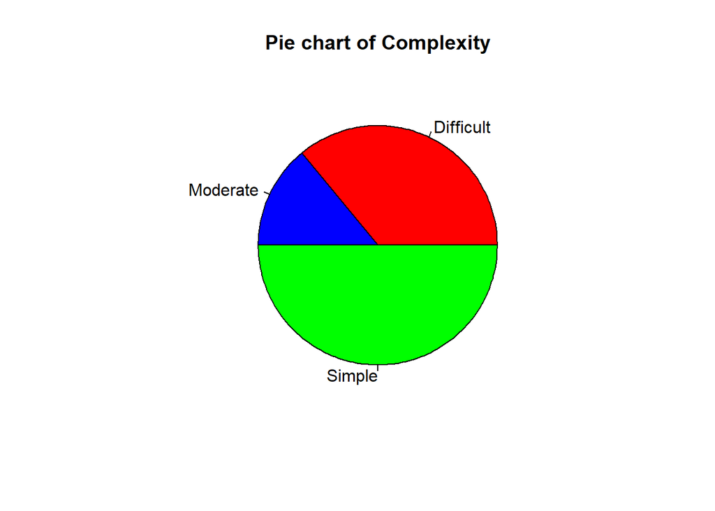

```r
# Visualisation for Categorical Variables

# Pie chart using the pie() function


pie(t1, main = 'Pie chart of Complexity',
    col = c('red', 'blue', 'green'))
```

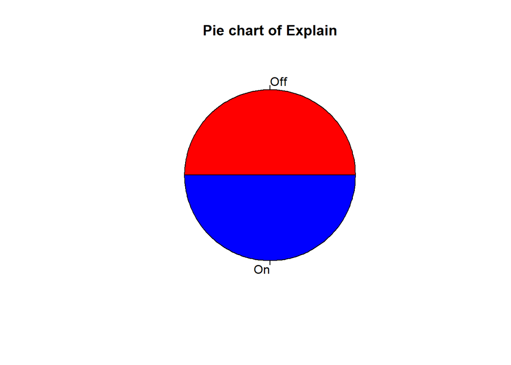

```r
pie(t2, main = 'Pie chart of Explain',
    col = c('red', 'blue'))
```

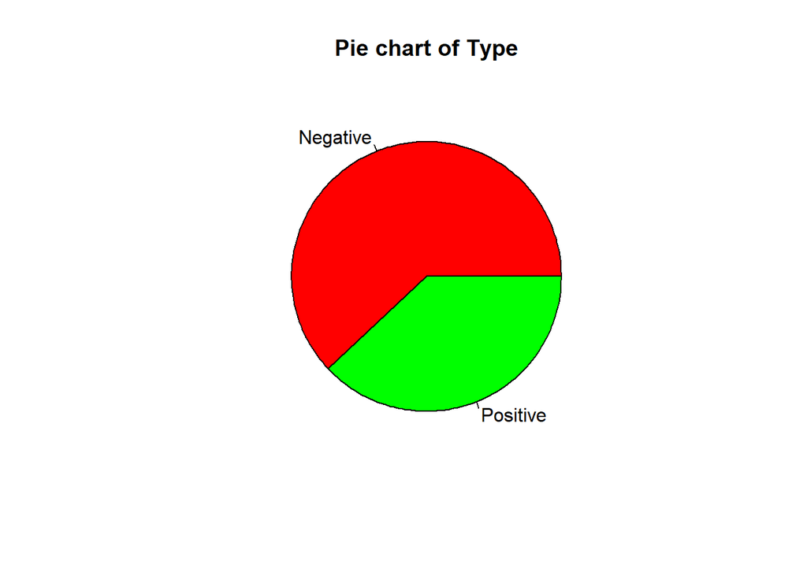

```r
pie(t3, main = 'Pie chart of Type',
    col = c('red', 'green'))
```

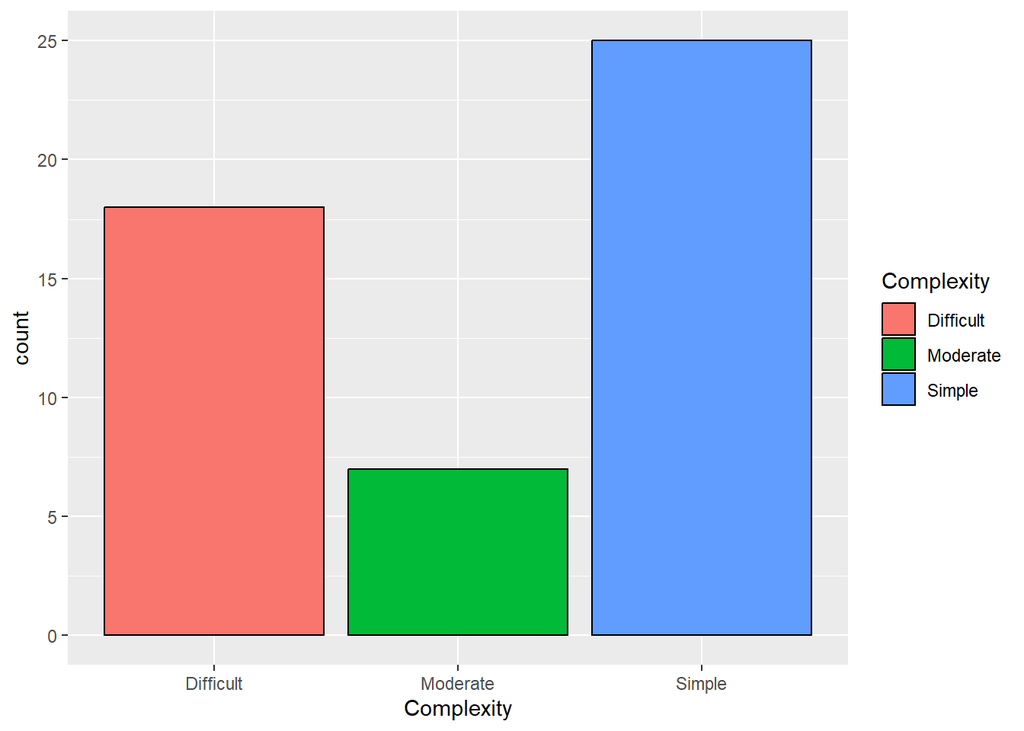

```r
ggplot(data = CW, aes(x = Complexity, fill = Complexity)) + geom_bar(color = 'black')
```

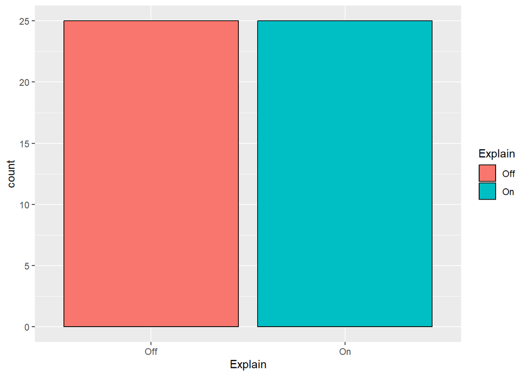

```r
ggplot(data = CW, aes(x = Explain, fill = Explain)) + geom_bar(color = 'black')
```

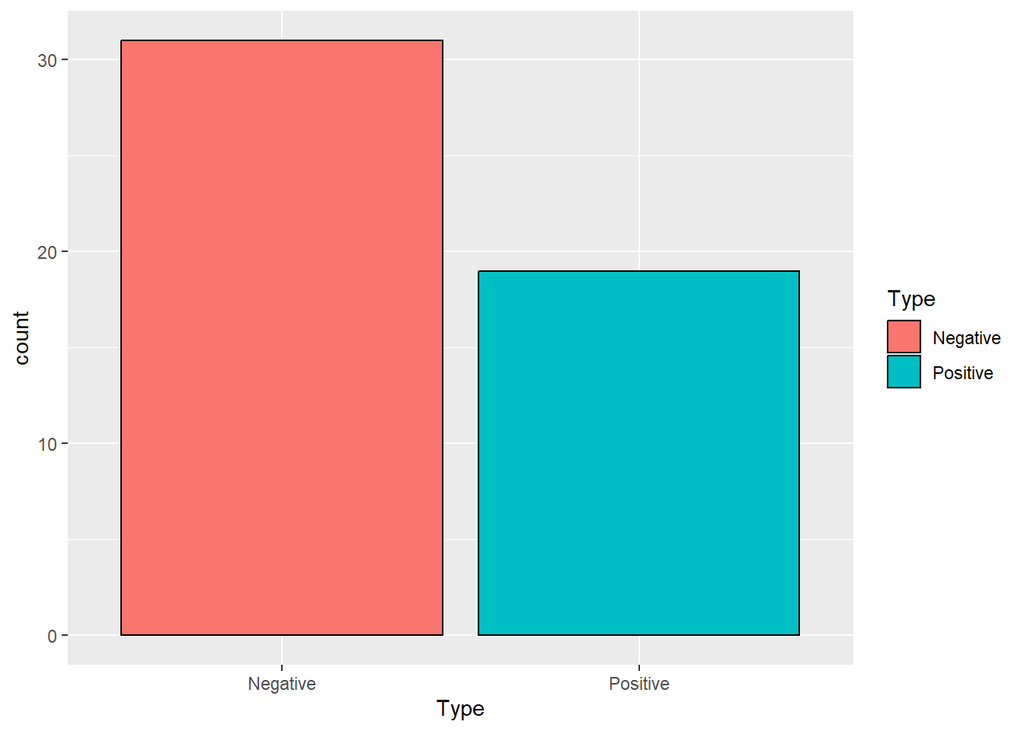

```r
ggplot(data = CW, aes(x = Type, fill = Type)) + geom_bar(color = 'black')
```

## Cross-tabulation can be done by table function

```r
# cross-tabulation can be done by table function
table(CW$Complexity, CW$Type)
```

```
##
##             Negative Positive
##   Difficult        8       10
##   Moderate         5        2
##   Simple          18        7
```

```r
table(CW$Complexity, CW$Explain)
```

```
##
##             Off On
##   Difficult  13  5
##   Moderate    5  2
##   Simple      7 18
```

```r
table(CW$Explain, CW$Type)
```

```
##
##       Negative Positive
##   Off       16        9
##   On        15       10
```

## Visualising Dependence of Two Categories

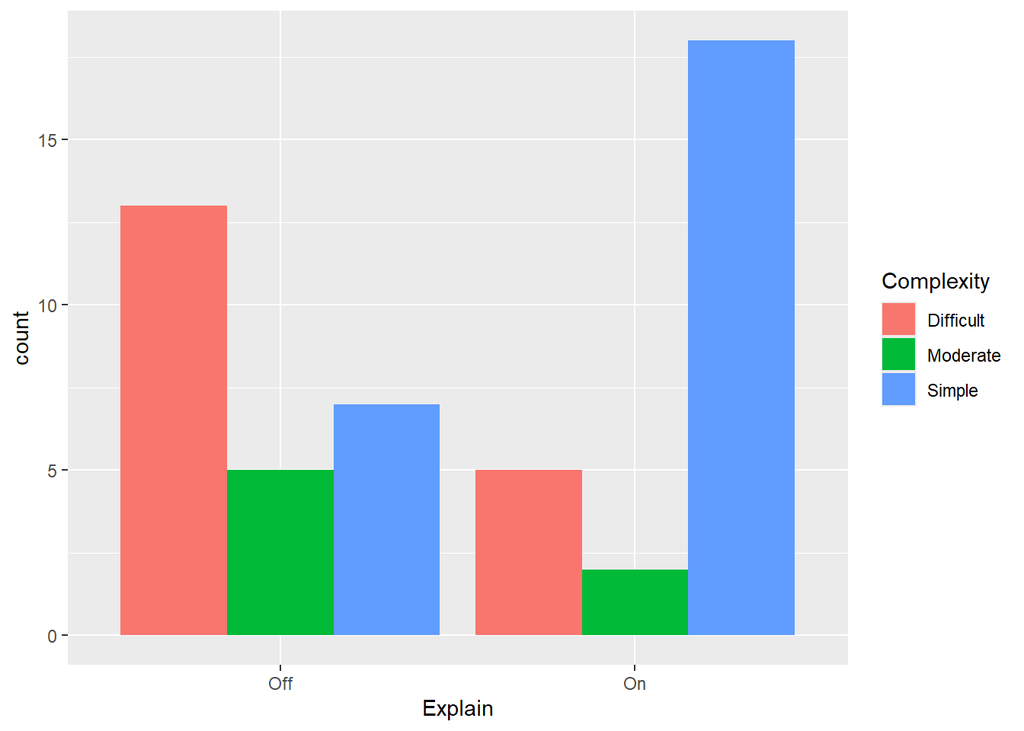

```r
# A grouped bar plot has a main variable, the secondary variable specified as the fill, and position set to 'dodge'
ggplot(data = CW, aes(x = Explain, fill = Complexity)) + geom_bar(position = "dodge")
```

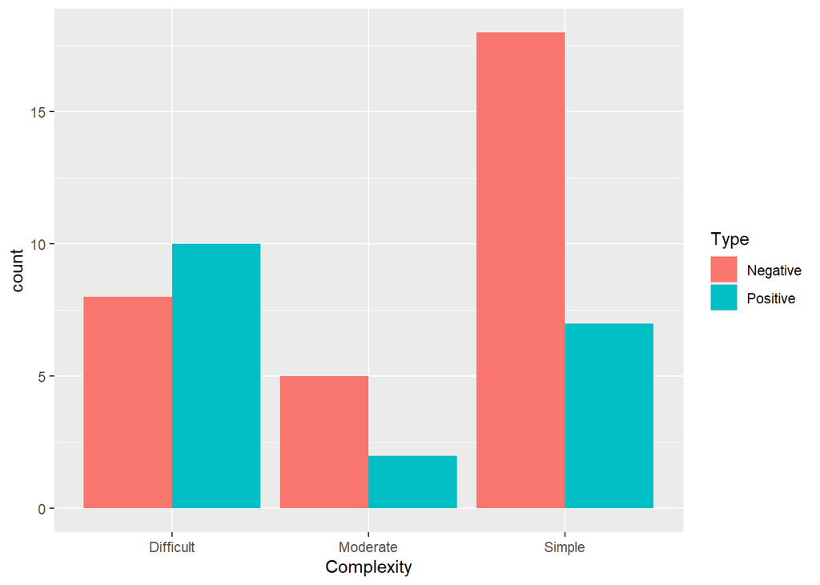

```r
ggplot(data = CW, aes(x = Complexity, fill = Type)) + geom_bar(position = "dodge")
```

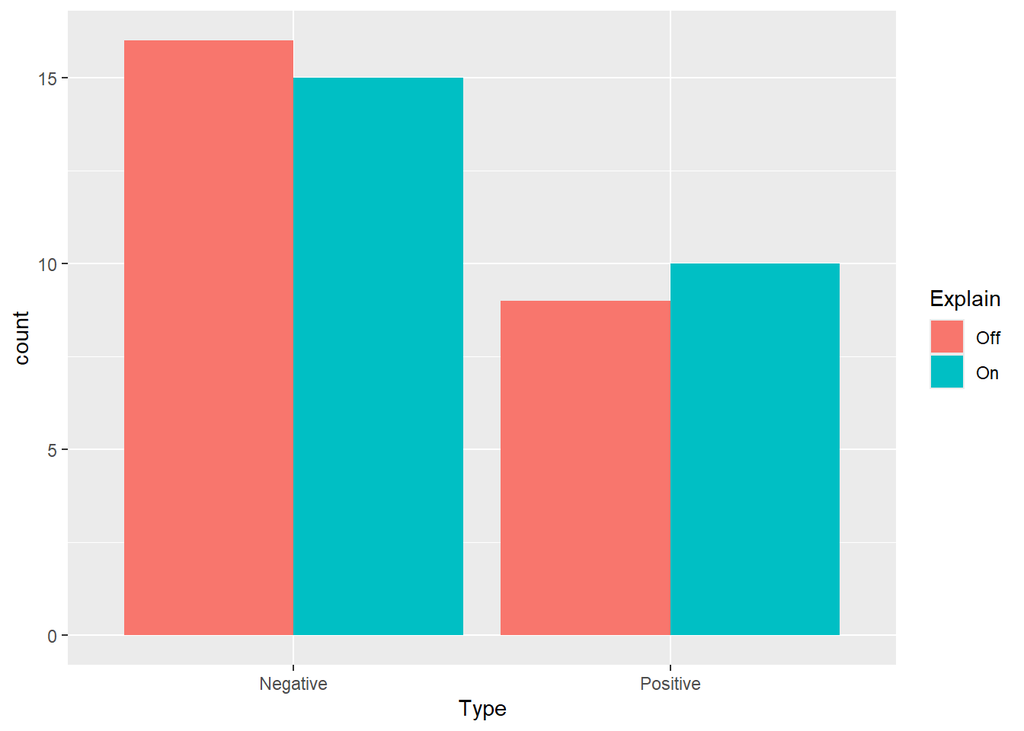

```r
ggplot(data = CW, aes(x = Type, fill = Explain)) + geom_bar(position = "dodge")
```

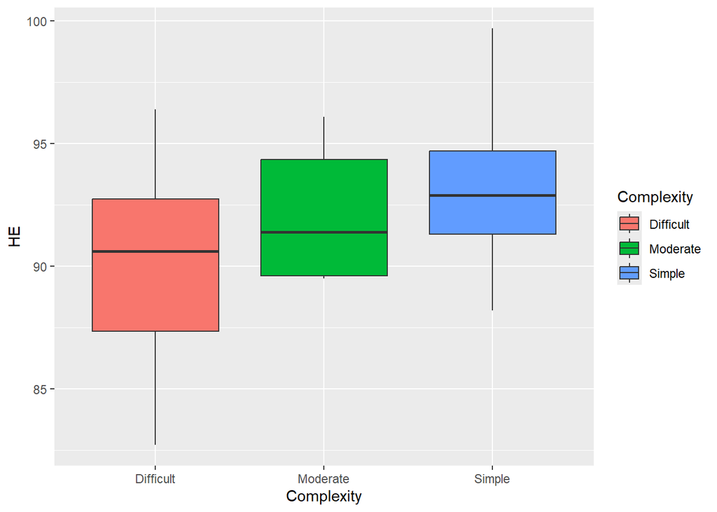

```r
# boxplots of HE broken down by Complexity category
ggplot(data = CW, aes(y = HE, x = Complexity, fill = Complexity)) + geom_boxplot()
```

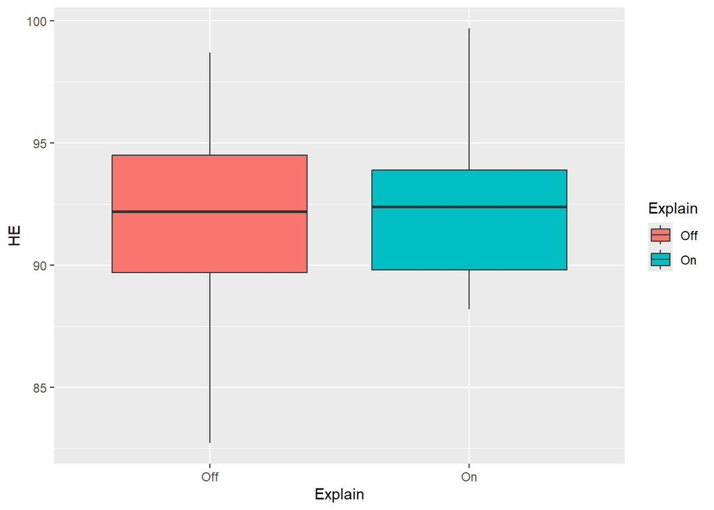

```r
ggplot(data = CW, aes(y = HE, x = Explain, fill = Explain)) + geom_boxplot()
```

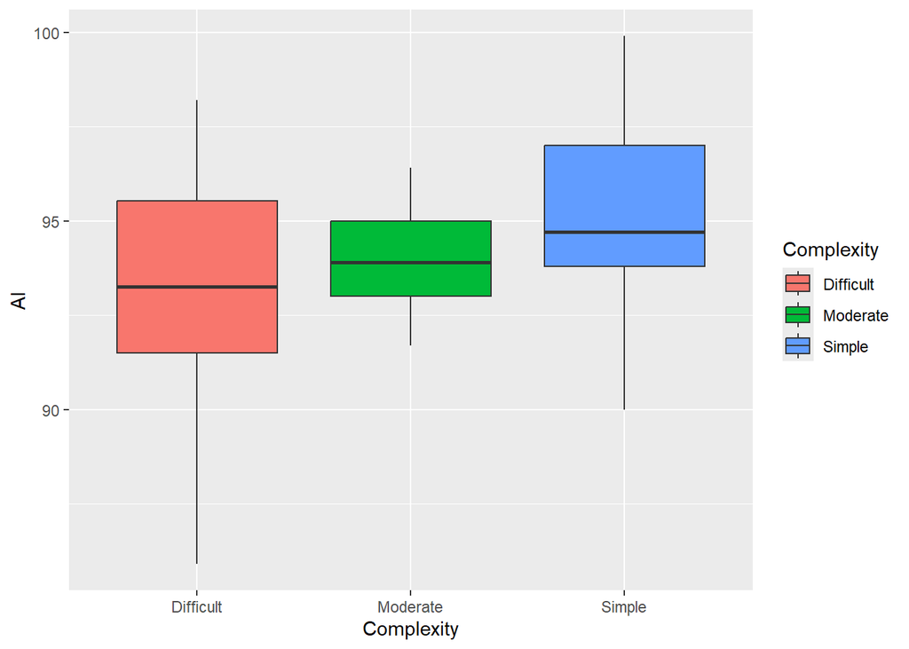

```r
ggplot(data = CW, aes(y = AI, x = Complexity, fill = Complexity)) + geom_boxplot()
```

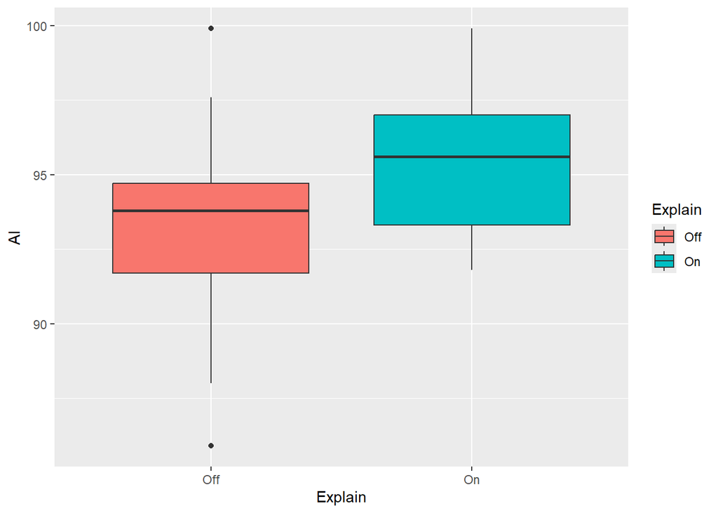

```r
# boxplots of AI broken down by Explain category
ggplot(data = CW, aes(y = AI, x = Explain, fill = Explain)) + geom_boxplot()
```

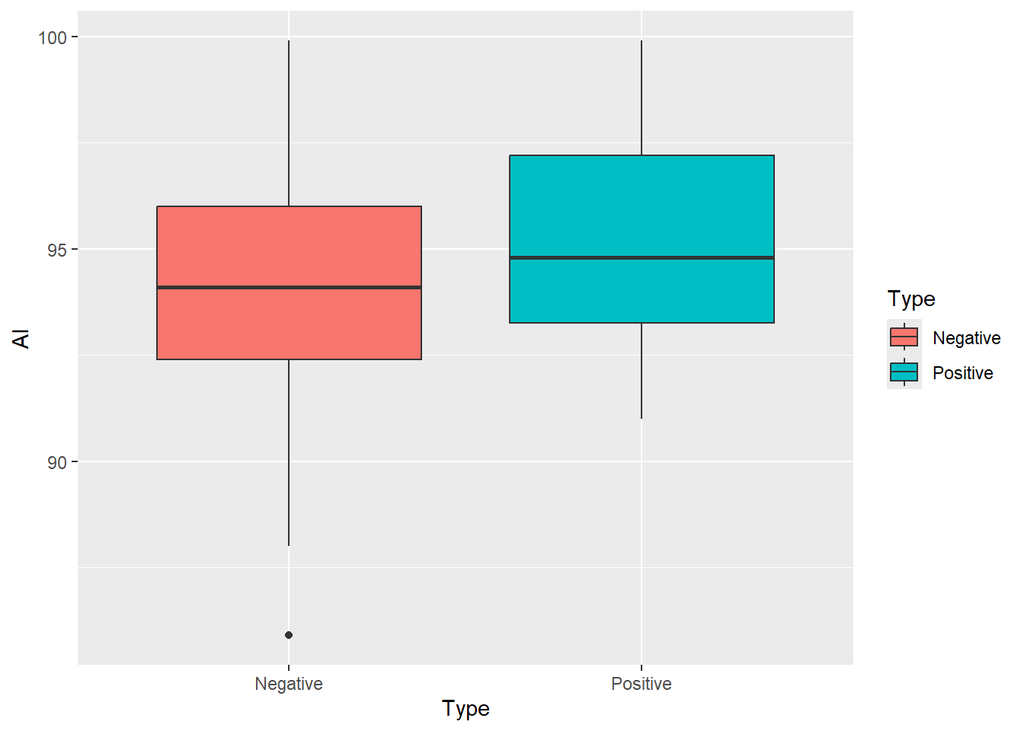

```r
ggplot(data = CW, aes(y = AI, x = Type, fill = Type)) + geom_boxplot()
```

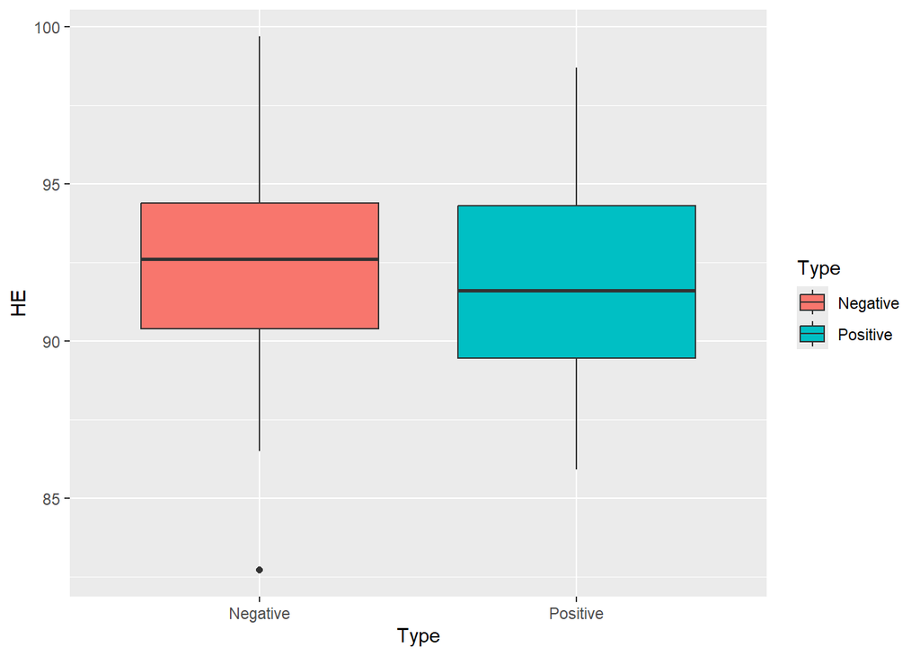

```r
ggplot(data = CW, aes(y = HE, x = Type, fill = Type)) + geom_boxplot()
```

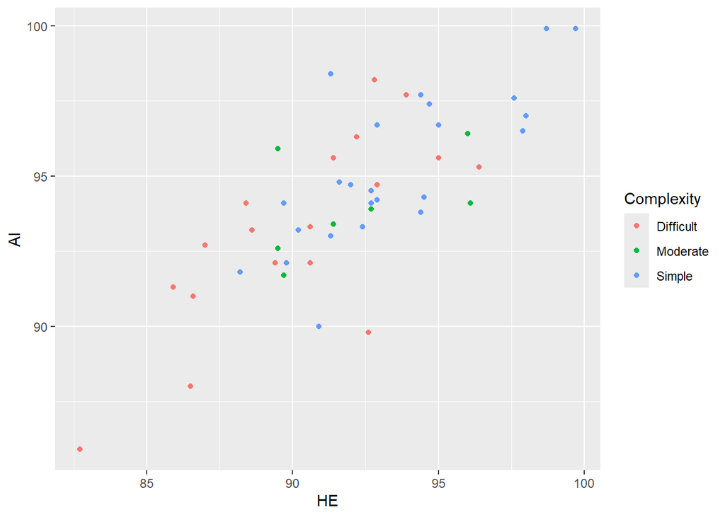

```r
# Exploring Dependence between Numerical Variables

# Scatter Plots
ggplot(data = CW, aes(x = HE, y = AI, color = Complexity)) + geom_point()
```

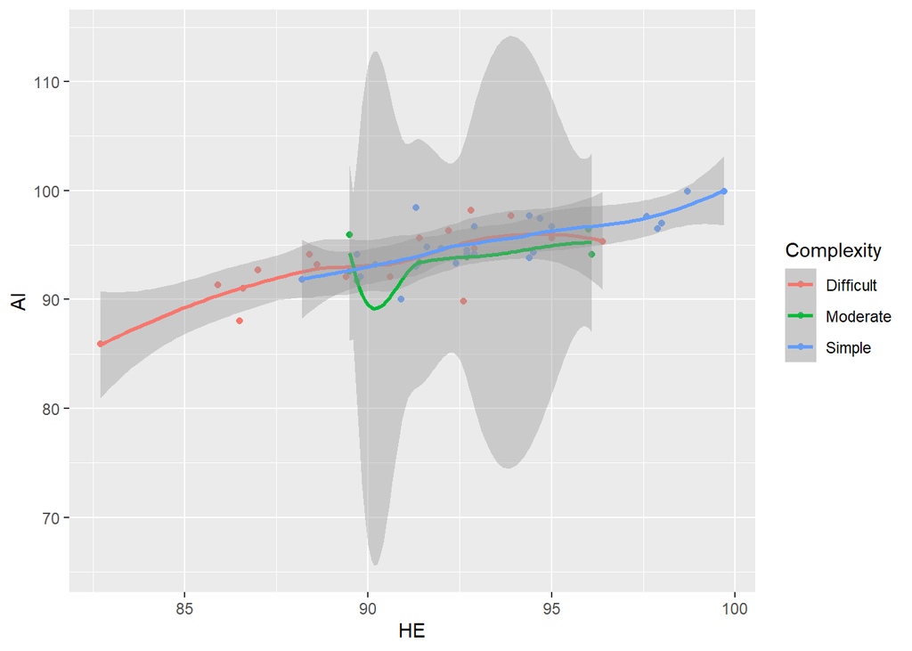

```r
ggplot(data = CW, aes(x = HE, y = AI, color = Complexity)) + geom_point() + geom_smooth()
```

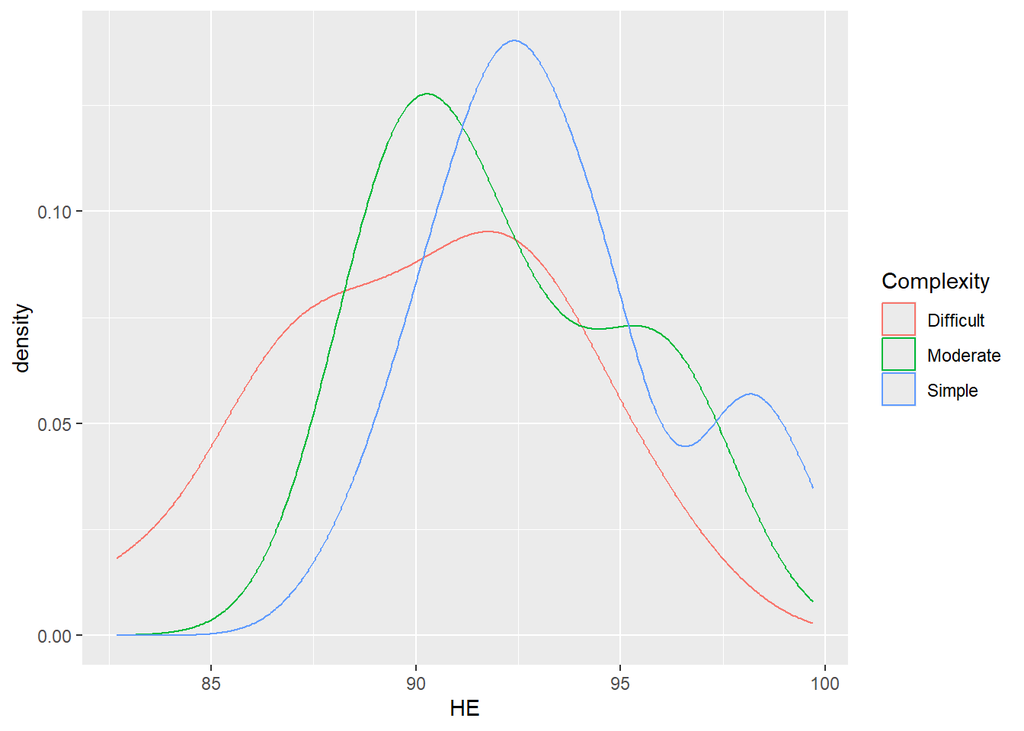

```r
ggplot(data = CW, aes(x = HE, color = Complexity)) +
  geom_density()
```

Show a normal distribution for all complexity catergory againt the Human Experts with simple being the highest

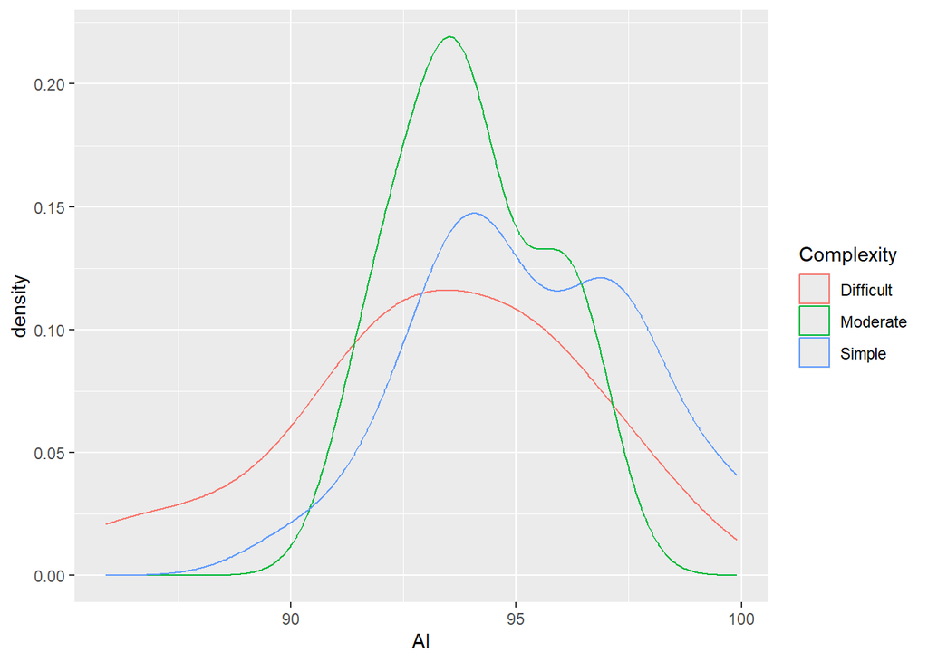

```r
ggplot(data = CW, aes(x = AI, color = Complexity)) +
  geom_density()
```

Show a normal distribution for all complexity catergory againt the Human AI with Moderate being the highest

```r
#Summarizing nummerical column by complexity category
summarize(CW, mean = mean(HE),
 median = median(HE), .by = Complexity)
```

```
##   Complexity     mean median
## 1     Simple 93.45600   92.9
## 2  Difficult 90.19444   90.6
## 3   Moderate 92.12857   91.4
```

```r
summarize(CW, mean = mean(AI),
 median = median(AI), .by = Complexity)
```

```
##   Complexity     mean median
## 1     Simple 95.29600  94.70
## 2  Difficult 93.16111  93.25
## 3   Moderate 94.00000  93.90
```

Statistics and visualisations seem to suggest some variation in means between the groups

## Anova test

ANOVA Procedure • Define our Hypothesis: • H0 : null hypothesis: All group means are the same µ1 = µ2 = µ3 • H1 : alternative hypothesis: At least 2 of the group means are different.

Applying the one-way ANOVA test

Now the one-way ANOVA test can be applied

```r
anovaHE = aov(HE ~ Complexity, data = CW)
summary(anovaHE)
```

```
##             Df Sum Sq Mean Sq F value  Pr(>F)
## Complexity   2  111.3   55.67   5.326 0.00823 **
## Residuals   47  491.3   10.45
## ---
## Signif. codes:  0 '***' 0.001 '**' 0.01 '*' 0.05 '.' 0.1 ' ' 1
```

```r
anovaAI = aov(AI ~ Complexity, data = CW)
summary(anovaAI)
```

```
##             Df Sum Sq Mean Sq F value Pr(>F)
## Complexity   2   48.7  24.336   3.322 0.0447 *
## Residuals   47  344.3   7.326
## ---
## Signif. codes:  0 '***' 0.001 '**' 0.01 '*' 0.05 '.' 0.1 ' ' 1
```

It indicates the probability of observing an F-statistic as extreme as, or more extreme than, the one observed, under the null hypothesis that there is no significant difference between the groups defined by ‘Complexity’. In this case, it’s 0.0447, which is less than the conventional significance level of 0.05. p < 0.05 (0.0447) so we can reject the null hypothesis enough evidence to say that Complexity affects the AI. Overall, the output suggests that there is a statistically significant effect of the ‘Complexity’ variable on the dependent variable AI, based on the ANOVA test conducted.

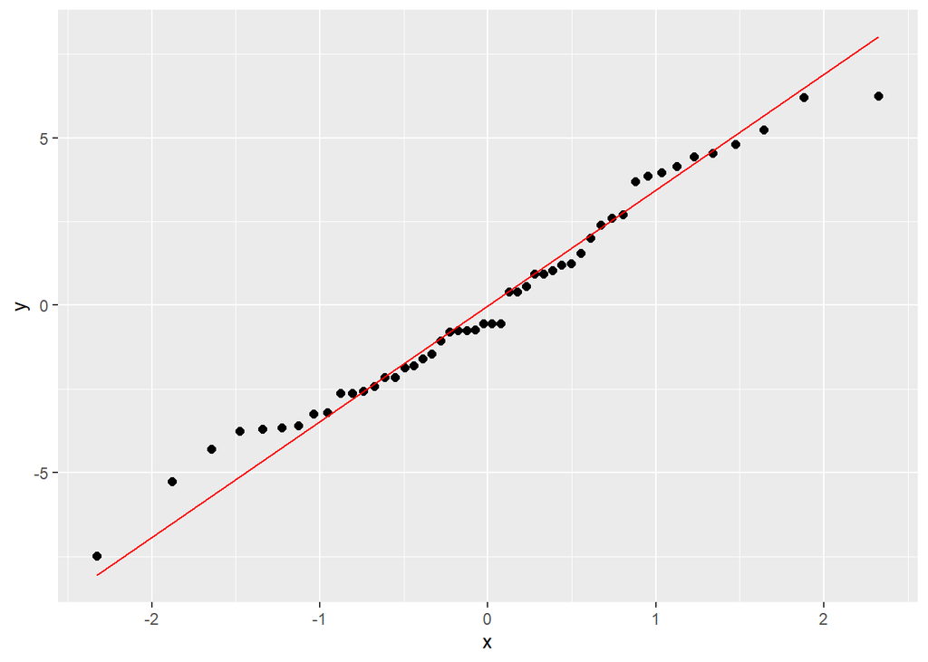

```r
CW$residuals = anovaHE$residuals
ggplot(CW, aes(sample = residuals)) +
 stat_qq(size=2) + stat_qq_line( col = 'red')
```

The points are close to the theoretical line. It is reasonable to assume the distribution is normal.

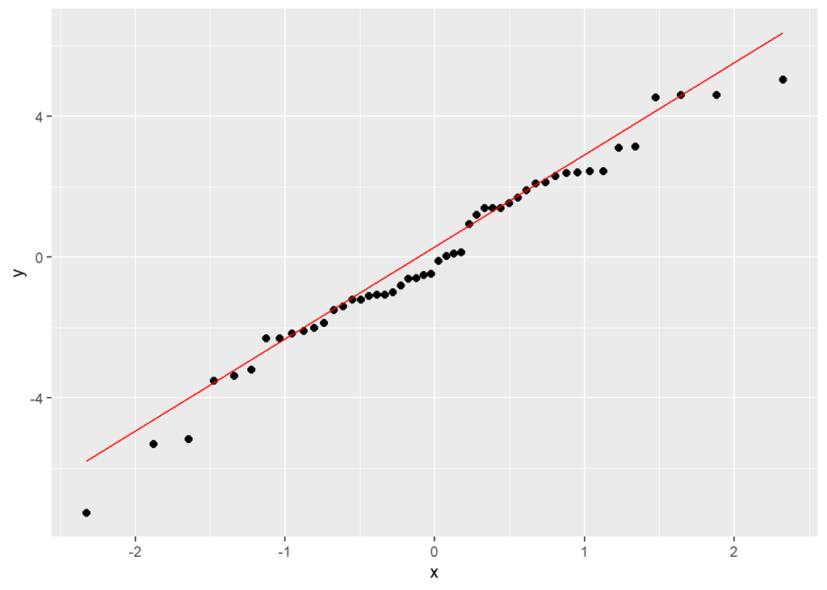

```r
CW$residuals = anovaAI$residuals
ggplot(CW, aes(sample = residuals)) +
 stat_qq(size=2) + stat_qq_line( col = 'red')
```

The points are close to the theoretical line. It is reasonable to assume the distribution is normal.

## Shapiro-Wilk test of normality

```r
## Normality test for HE
shapiro.test(anovaHE$residuals)
```

```
##
##  Shapiro-Wilk normality test
##
## data:  anovaHE$residuals
## W = 0.97778, p-value = 0.4626
```

Since the p-value (0.4626) is greater than the significance level (0.05), we fail to reject the null hypothesis. Therefore, we do not have sufficient evidence to conclude that the residuals significantly deviate from a normal distribution. This suggests that the assumption of normality for the residuals in the ANOVA analysis is met, indicating that the model’s residuals follow a normal distribution.

```r
## Normality test for AI
shapiro.test(anovaAI$residuals)
```

```
##
##  Shapiro-Wilk normality test
##
## data:  anovaAI$residuals
## W = 0.97733, p-value = 0.4456
```

The p-value (0.4456) is greater than the significance level (0.05), we fail to reject the null hypothesis. Therefore, we do not have sufficient evidence to conclude that the residuals significantly deviate from a normal distribution. This suggests that the assumption of normality for the residuals in the ANOVA analysis is met, indicating that the model’s residuals follow a normal distribution.

Both normality checks suggest it is reasonable to assume residuals are normally distributed. Hence in this case the ANOVA test is VALID

## Kruskal-Wallis rank sum test

```r
kruskal.test(AI ~ HE, data = CW)
```

```
##
##  Kruskal-Wallis rank sum test
##
## data:  AI by HE
## Kruskal-Wallis chi-squared = 41.276, df = 37, p-value = 0.2891
```

Since the p-value (0.2891) is greater than the significance level (such as 0.05), we fail to reject the null hypothesis. Therefore, there is insufficient evidence to conclude that there are significant differences in medians between the groups. In other words, based on this test, there is no statistically significant difference in the ‘AI’ variable across the different levels of the ‘HE’ variable.

```r
kruskal.test(HE ~ Complexity, data = CW)
```

```
##
##  Kruskal-Wallis rank sum test
##
## data:  HE by Complexity
## Kruskal-Wallis chi-squared = 7.609, df = 2, p-value = 0.02227
```

p < 0.05 (0.02227) so REJECT the null hypothesis. The Kruskal-Wallis test indicates that there are statistically significant differences in the medians of the ‘HE’ variable across different levels of the ‘Complexity’ variable.

```r
kruskal.test(HE ~ Type, data = CW)
```

```
##
##  Kruskal-Wallis rank sum test
##
## data:  HE by Type
## Kruskal-Wallis chi-squared = 0.28082, df = 1, p-value = 0.5962
```

Since the p-value (0.5962) exceeds the significance level (such as 0.05), we do not reject the null hypothesis. Hence, there is inadequate evidence to conclude that there are significant differences in medians between the groups defined by the ‘HE’ variable across different levels of ‘Type’. According to the Kruskal-Wallis test results, there are no statistically significant differences in the medians of the ‘HE’ variable across different levels of the ‘Type’ variable.

```r
kruskal.test(AI ~ Explain, data = CW)
```

```
##
##  Kruskal-Wallis rank sum test
##
## data:  AI by Explain
## Kruskal-Wallis chi-squared = 6.7677, df = 1, p-value = 0.009282
```

Since the p-value (0.009282) is less than the significance level (such as 0.05), we reject the null hypothesis. Therefore, we have sufficient evidence to conclude that there are significant differences in medians between the groups defined by the ‘AI’ variable across different levels of ‘Explain’. In other words, the ‘Explain’ variable significantly affects the ‘AI’ variable. In summary, the Kruskal-Wallis test indicates that there are statistically significant differences in the medians of the ‘AI’ variable across different levels of the ‘Explain’ variable.

```r
kruskal.test(AI ~ Type, data = CW)
```

```
##
##  Kruskal-Wallis rank sum test
##
## data:  AI by Type
## Kruskal-Wallis chi-squared = 1.9597, df = 1, p-value = 0.1615
```

The p-value (0.1615) is greater than the significance level (such as 0.05), we do not reject the null hypothesis. There is insufficient evidence to conclude that there are significant differences in medians between the groups defined by the ‘AI’ variable across different levels of ‘Type’. In other words, the ‘Type’ variable does not significantly influence the ‘AI’ variable. In summary, according to the Kruskal-Wallis test results, there are no statistically significant differences in the medians of the ‘AI’ variable across different levels of the ‘Type’ variable.

```r
kruskal.test(AI ~ Complexity, data = CW)
```

```
##
##  Kruskal-Wallis rank sum test
##
## data:  AI by Complexity
## Kruskal-Wallis chi-squared = 5.466, df = 2, p-value = 0.06503
```

The p-value (0.06503) is slightly greater than the significance level (such as 0.05), we do not have strong evidence to reject the null hypothesis. Therefore, there is not enough evidence to conclude that there are significant differences in medians between the groups defined by the ‘AI’ variable across different levels of ‘Complexity’. However, it is worth noting that the p-value is close to the significance level, suggesting a marginal level of significance. In summary, according to the Kruskal-Wallis test results, there may not be statistically significant differences in the medians of the ‘AI’ variable across different levels of the ‘Complexity’ variable, although the result is borderline and may warrant further investigation.

## Two way Anova

```r
round(tapply(CW$AI, list(CW$Complexity, CW$Explain), FUN = mean),2)
```

```
##             Off    On
## Difficult 92.16 95.76
## Moderate  93.90 94.25
## Simple    94.91 95.44
```

```r
round(tapply(CW$HE, list(CW$Complexity, CW$Type), FUN = mean),2)
```

```
##           Negative Positive
## Difficult    90.00    90.35
## Moderate     93.18    89.50
## Simple       92.88    94.94
```

```r
anova2HE = aov(HE ~ Complexity + Type, data = CW)
summary(anova2HE)
```

```
##             Df Sum Sq Mean Sq F value  Pr(>F)
## Complexity   2  111.3   55.67   5.256 0.00879 **
## Type         1    4.1    4.12   0.389 0.53583
## Residuals   46  487.2   10.59
## ---
## Signif. codes:  0 '***' 0.001 '**' 0.01 '*' 0.05 '.' 0.1 ' ' 1
```

For Complexity, the p-value is 0.00879, which is less than the conventional significance level of 0.05, indicating significance. For Type, the p-value is 0.53583, which is greater than 0.05, indicating non-significance. In summary, the ANOVA test suggests that Complexity has a significant effect on the dependent variable HE, while Type does not.

```r
anova2AI = aov(AI ~ Complexity + Explain, data = CW)
summary(anova2AI)
```

```
##             Df Sum Sq Mean Sq F value Pr(>F)
## Complexity   2   48.7  24.336   3.516 0.0379 *
## Explain      1   25.9  25.929   3.746 0.0591 .
## Residuals   46  318.4   6.921
## ---
## Signif. codes:  0 '***' 0.001 '**' 0.01 '*' 0.05 '.' 0.1 ' ' 1
```

For Complexity, the p-value is 0.0379, which is less than the conventional significance level of 0.05, indicating significance. For Explain, the p-value is 0.0591, which is close to 0.05 but still greater, suggesting marginal significance. The ANOVA test suggests that Complexity has a significant effect on the dependent variable AI, while Explain has a marginally significant effect.

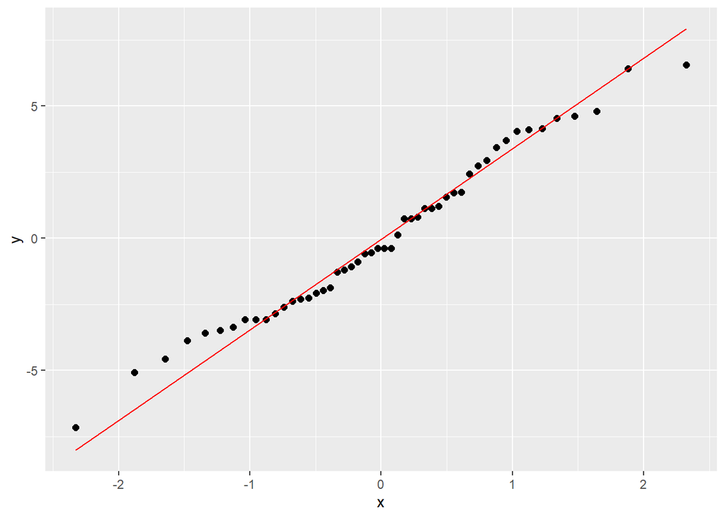

```r
CW$residualHE = anova2HE$residuals
ggplot(CW, aes(sample = residualHE)) +
 stat_qq(size=2) + stat_qq_line( col = 'red')
```

```r
shapiro.test(anova2HE$residuals)
```

```
##
##  Shapiro-Wilk normality test
##
## data:  anova2HE$residuals
## W = 0.97927, p-value = 0.5217
```

Since the p-value (0.5217) is greater than the common significance level of 0.05, we fail to reject the null hypothesis. Therefore, there is not enough evidence to conclude that the residuals significantly deviate from a normal distribution. In other words, based on this test, we can assume that the residuals are approximately normally distributed. In summary, the Shapiro-Wilk normality test suggests that there is no significant departure from normality in the residuals of the statistical analysis. Hence, assumptions related to the normality of residuals in the underlying statistical model may be considered adequately met.

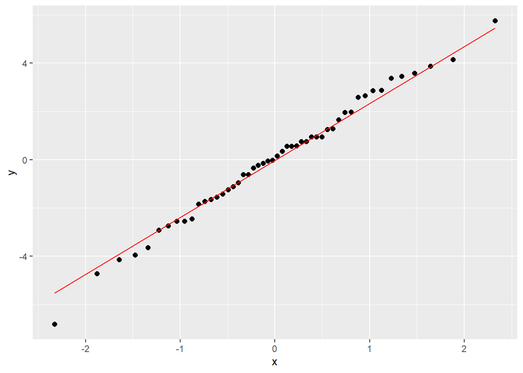

```r
CW$residualAI = anova2AI$residuals
ggplot(CW, aes(sample = residualAI)) +
 stat_qq(size=2) + stat_qq_line( col = 'red')
```

```r
shapiro.test(anova2AI$residuals)
```

```
##
##  Shapiro-Wilk normality test
##
## data:  anova2AI$residuals
## W = 0.99307, p-value = 0.9916
```

The p-value (0.9916) is much greater than the significance level of 0.05, we fail to reject the null hypothesis. Therefore, there is insufficient evidence to conclude that the residuals significantly deviate from a normal distribution.Based on this test, we can assume that the residuals are approximately normally distributed. In summary, the Shapiro-Wilk normality test suggests that there is no significant departure from normality in the residuals of the statistical analysis. Hence, assumptions related to the normality of residuals in the underlying statistical model may be considered adequately met.

The p-value is > 0.05 so it is reasonable to assume normality.

```r
H = TukeyHSD(anova2HE, which = "Complexity")
H
```

```
##   Tukey multiple comparisons of means
##     95% family-wise confidence level
##
## Fit: aov(formula = HE ~ Complexity + Type, data = CW)
##
## $Complexity
##                        diff        lwr      upr     p adj
## Moderate-Difficult 1.934127 -1.5765173 5.444771 0.3837821
## Simple-Difficult   3.261556  0.8252595 5.697852 0.0061422
## Simple-Moderate    1.327429 -2.0427899 4.697647 0.6093829
```

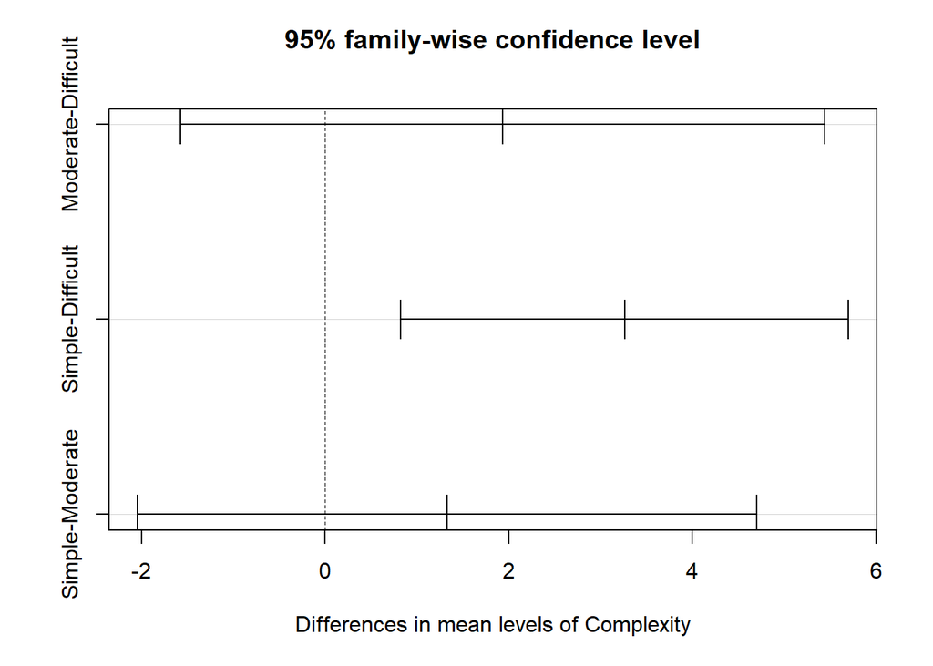

```r
plot(H)
```

```r
H2 = TukeyHSD(anova2AI, which = "Complexity")
H2
```

```
##   Tukey multiple comparisons of means
##     95% family-wise confidence level
##
## Fit: aov(formula = AI ~ Complexity + Explain, data = CW)
##
## $Complexity
##                         diff        lwr      upr     p adj
## Moderate-Difficult 0.8388889 -1.9991906 3.676968 0.7554100
## Simple-Difficult   2.1348889  0.1653353 4.104442 0.0308936
## Simple-Moderate    1.2960000 -1.4285564 4.020556 0.4875814
```

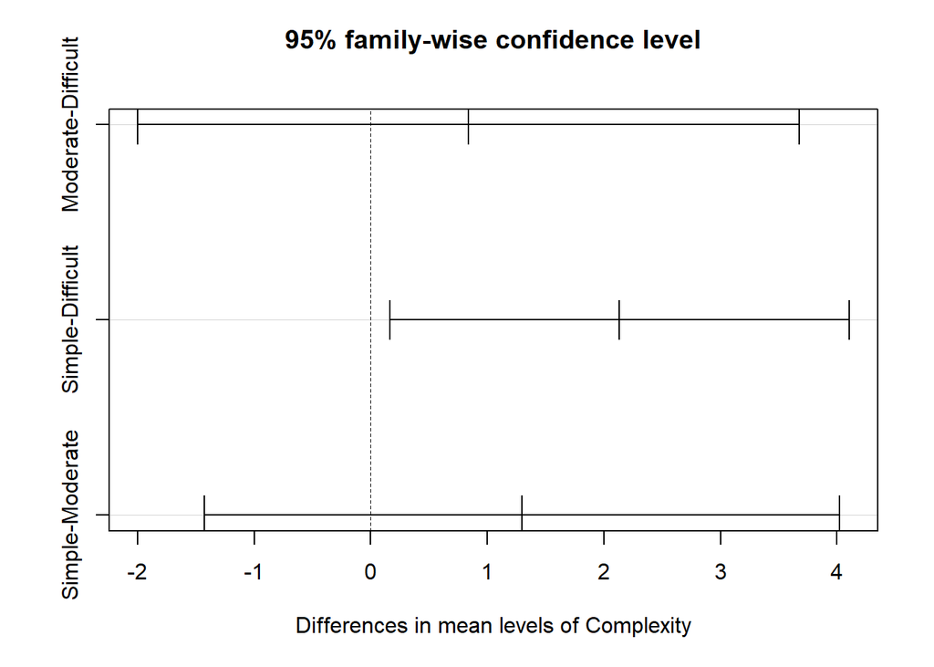

```r
plot(H2)
```

## Chi Squared Test

```r
resultsCE= chisq.test(CW$Complexity, CW$Explain)
resultsCE
```

```
##
##  Pearson's Chi-squared test
##
## data:  CW$Complexity and CW$Explain
## X-squared = 9.6813, df = 2, p-value = 0.007902
```

Since the p-value (0.007902) is less than 0.05, we reject the null hypothesis. There is sufficient evidence to conclude that there is a statistically significant association between the ‘Complexity’ and ‘Explain’ variables in the dataset. In other words, the variables ‘Complexity’ and ‘Explain’ are not independent of each other. In summary, based on Pearson’s Chi-squared test, there is a statistically significant association between the ‘Complexity’ and ‘Explain’ variables in the dataset.

```r
resultsCE$observed
```

```
##              CW$Explain
## CW$Complexity Off On
##     Difficult  13  5
##     Moderate    5  2
##     Simple      7 18
```

```r
round(resultsCE$expected,0)
```

```
##              CW$Explain
## CW$Complexity Off On
##     Difficult   9  9
##     Moderate    4  4
##     Simple     12 12
```

```r
round(resultsCE$residuals,2)
```

```
##              CW$Explain
## CW$Complexity   Off    On
##     Difficult  1.33 -1.33
##     Moderate   0.80 -0.80
##     Simple    -1.56  1.56
```

```r
resultsCT= chisq.test(CW$Complexity, CW$Type)
resultsCT
```

```
##
##  Pearson's Chi-squared test
##
## data:  CW$Complexity and CW$Type
## X-squared = 3.6799, df = 2, p-value = 0.1588
```

There is insufficient evidence to conclude that there is a statistically significant association between the ‘Complexity’ and ‘Type’ variables in the dataset. In other words, the variables ‘Complexity’ and ‘Type’ appear to be independent of each other. In summary, based on Pearson’s Chi-squared test, there is no statistically significant association between the ‘Complexity’ and ‘Type’ variables in the dataset.

```r
resultsCT$observed
```

```
##              CW$Type
## CW$Complexity Negative Positive
##     Difficult        8       10
##     Moderate         5        2
##     Simple          18        7
```

```r
round(resultsCT$expected,0)
```

```
##              CW$Type
## CW$Complexity Negative Positive
##     Difficult       11        7
##     Moderate         4        3
##     Simple          16       10
```

```r
round(resultsCT$residuals,2)
```

```
##              CW$Type
## CW$Complexity Negative Positive
##     Difficult    -0.95     1.21
##     Moderate      0.32    -0.40
##     Simple        0.64    -0.81
```

```r
resultsET= chisq.test(CW$Explain, CW$Type)
resultsET
```

```
##
##  Pearson's Chi-squared test with Yates' continuity correction
##
## data:  CW$Explain and CW$Type
## X-squared = 0, df = 1, p-value = 1
```

There is no evidence to suggest that there is a statistically significant association between the ‘Explain’ and ‘Type’ variables in the dataset. In other words, the variables ‘Explain’ and ‘Type’ appear to be independent of each other.

```r
resultsET$observed
```

```
##           CW$Type
## CW$Explain Negative Positive
##        Off       16        9
##        On        15       10
```

```r
round(resultsET$expected,0)
```

```
##           CW$Type
## CW$Explain Negative Positive
##        Off       16       10
##        On        16       10
```

```r
round(resultsET$residuals,2)
```

```
##           CW$Type
## CW$Explain Negative Positive
##        Off     0.13    -0.16
##        On     -0.13     0.16
```

```r
power.t.test(power = 0.99,delta = 2,sd = 3.2,sig.level = 0.01,
type = "two.sample", alternative = "two.sided")
```

```
##
##      Two-sample t test power calculation
##
##               n = 124.7135
##           delta = 2
##              sd = 3.2
##       sig.level = 0.01
##           power = 0.99
##     alternative = two.sided
##
## NOTE: n is number in *each* group
```

```r
test = power.t.test(power = 0.99,delta = 2,sd = 3.2,sig.level = 0.01,
type = "two.sample", alternative = "two.sided")
ceiling(test$n)
```

```
## [1] 125
```

## Wilcoxon signed rank test with continuity correction

```r
wilcox.test(CW$HE, y = NULL,
 alternative = "two.sided",
 mu = 400, paired = FALSE, exact = F, correct = T,
 conf.int = F, conf.level = 0.95)
```

```
##
##  Wilcoxon signed rank test with continuity correction
##
## data:  CW$HE
## V = 0, p-value = 7.754e-10
## alternative hypothesis: true location is not equal to 400
```

```r
wilcox.test(CW$AI, y = NULL,
 alternative = "two.sided",
 mu = 400, paired = FALSE, exact = F, correct = T,
 conf.int = F, conf.level = 0.95)
```

```
##
##  Wilcoxon signed rank test with continuity correction
##
## data:  CW$AI
## V = 0, p-value = 7.748e-10
## alternative hypothesis: true location is not equal to 400
```

```r
wilcox.test(CW$AI, y = CW$HE,
 alternative = "two.sided",
 mu = 400, paired = FALSE, exact = F, correct = T,
 conf.int = F, conf.level = 0.95)
```

```
##
##  Wilcoxon rank sum test with continuity correction
##
## data:  CW$AI and CW$HE
## W = 0, p-value < 2.2e-16
## alternative hypothesis: true location shift is not equal to 400
```